# NBA19-20

Jaehack

1. Loading the season data and extracting some meaningful statistics
- field goals made
- three points made
- free throws made
- total rebounds
- total points

```r
library(SportsAnalytics)

nba1920 <- fetch_NBAPlayerStatistics("19-20")

player_stat <- nba1920[, c("Name", "Team", "FieldGoalsMade", "ThreesMade", "FreeThrowsMade", "TotalRebounds",
                           "TotalPoints")]
```

2. Subsetting the data to include only players for LAL, the champion of 19-20 season and finding the players who are “best” for some meaningful stats.

```r
LAL_subset <- subset(nba1920, Team == 'LAL')
sub <- matrix(c(LAL_subset[which.max(LAL_subset$FieldGoalsMade), c("Name", "FieldGoalsMade")],
LAL_subset[which.max(LAL_subset$ThreesMade), c("Name", "ThreesMade")],
LAL_subset[which.max(LAL_subset$FreeThrowsMade), c("Name", "FreeThrowsMade")],
LAL_subset[which.max(LAL_subset$TotalRebounds), c("Name", "TotalRebounds")],
LAL_subset[which.max(LAL_subset$TotalPoints), c("Name", "TotalPoints")]), ncol = 2, byrow = TRUE)
colnames(sub) <- c("Player", "Statistics")
rownames(sub) <- c("Field Goals Made", "Three Points Made", "Free Throws Made", "Total Rebounds",
                   "Total Points")
sub
```

```
##                   Player          Statistics
## Field Goals Made  "Lebron James"  643
## Three Points Made "Lebron James"  148
## Free Throws Made  "Anthony Davis" 444
## Total Rebounds    "Anthony Davis" 576
## Total Points      "Lebron James"  1698
```

3. Showing 5 teams for the season that have the most wins in descending order.

```r
library(rvest)
reg_season1920 <- read_html("https://en.wikipedia.org/wiki/2019%E2%80%9320_NBA_season")
reg_season_data <- reg_season1920 %>% html_nodes("table.wikitable")

#By Division
East_ATL_Div <- (reg_season_data[2] %>% html_table)[[1]]  # Eastern Conference - Atlantic Division
East_CEN_Div <- (reg_season_data[3] %>% html_table)[[1]]  # Eastern Conference - Central Division
East_SOU_Div <- (reg_season_data[4] %>% html_table)[[1]]  # Eastern Conference - Southeast Division

West_NOR_Div <- (reg_season_data[5] %>% html_table)[[1]]  # Western Conference - Northwest Division
West_PAC_Div <- (reg_season_data[6] %>% html_table)[[1]]  # Western Conference - Pacific Division
West_SOU_Div <- (reg_season_data[7] %>% html_table)[[1]]  # Western Conference - Southhwest Division

#Getting rid of unnecessary indications on the Team names
East_ATL_Div$`Atlantic Division` <- gsub("y – ", "", East_ATL_Div$`Atlantic Division`)
East_ATL_Div$`Atlantic Division` <- gsub("x – ", "", East_ATL_Div$`Atlantic Division`)

East_CEN_Div$`Central Division` <- gsub("z – ", "", East_CEN_Div$`Central Division`)
East_CEN_Div$`Central Division` <- gsub("x – ", "", East_CEN_Div$`Central Division`)

East_SOU_Div$`Southeast Division` <- gsub("y – ", "", East_SOU_Div$`Southeast Division`)
East_SOU_Div$`Southeast Division` <- gsub("x – ", "", East_SOU_Div$`Southeast Division`)

West_NOR_Div$`Northwest Division` <- gsub("y – ", "", West_NOR_Div$`Northwest Division`)
West_NOR_Div$`Northwest Division` <- gsub("x – ", "", West_NOR_Div$`Northwest Division`)

West_PAC_Div$`Pacific Division` <- gsub("c – ", "", West_PAC_Div$`Pacific Division`)
West_PAC_Div$`Pacific Division` <- gsub("x – ", "", West_PAC_Div$`Pacific Division`)

West_SOU_Div$`Southwest Division` <- gsub("y – ", "", West_SOU_Div$`Southwest Division`)
West_SOU_Div$`Southwest Division` <- gsub("x – ", "", West_SOU_Div$`Southwest Division`)

East_ATL_Div
```

```
##    Atlantic Division  W  L   PCT   GB  Home  Road  Div GP
## 1    Toronto Raptors 53 19 0.736  0.0 26–10  27–9  9–5 72
## 2     Boston Celtics 48 24 0.667  5.0 26–10 22–14  9–6 72
## 3 Philadelphia 76ers 43 30 0.589 10.5  31–4 12–26 11–5 73
## 4      Brooklyn Nets 35 37 0.486 18.0 20–16 15–21 6–10 72
## 5    New York Knicks 21 45 0.318 29.0 11–22 10–23 2–11 66
```

```r
East_CEN_Div
```

```
##      Central Division  W  L   PCT   GB  Home  Road  Div GP
## 1     Milwaukee Bucks 56 17 0.767  0.0  30–5 26–12 13–1 73
## 2      Indiana Pacers 45 28 0.616 11.0 25–11 20–17  8–7 73
## 3       Chicago Bulls 22 43 0.338 30.0 14–20  8–23  7–9 65
## 4     Detroit Pistons 20 46 0.303 32.5 11–22  9–24 5–10 66
## 5 Cleveland Cavaliers 19 46 0.292 33.0 11–25  8–21 4–10 65
```

```r
East_SOU_Div
```

```
##   Southeast Division  W  L   PCT   GB  Home  Road  Div GP
## 1         Miami Heat 44 29 0.603  0.0  29–7 15–22 10–4 73
## 2      Orlando Magic 33 40 0.452 11.0 18–17 15–23  9–5 73
## 3 Washington Wizards 25 47 0.347 18.5 16–20  9–27  5–9 72
## 4  Charlotte Hornets 23 42 0.354 17.0 10–21 13–21  2–7 65
## 5      Atlanta Hawks 20 47 0.299 21.0 14–20  6–27  6–7 67
```

```r
West_NOR_Div
```

```
##       Northwest Division  W  L   PCT   GB  Home  Road  Div GP
## 1         Denver Nuggets 46 27 0.630  0.0 26–11 20–16 12–2 73
## 2  Oklahoma City Thunder 44 28 0.611  1.5 23–14 21–14  8–5 72
## 3              Utah Jazz 44 28 0.611  1.5 23–12 21–16  5–7 72
## 4 Portland Trail Blazers 35 39 0.473 11.5 21–15 14–24  5–8 74
## 5 Minnesota Timberwolves 19 45 0.297 22.5  8–24 11–21 2–10 64
```

```r
West_PAC_Div
```

```
##        Pacific Division  W  L   PCT   GB  Home  Road  Div GP
## 1    Los Angeles Lakers 52 19 0.732  0.0 25–10  27–9 10–3 71
## 2  Los Angeles Clippers 49 23 0.681  3.5  27–9 22–14  8–6 72
## 3          Phoenix Suns 34 39 0.466 19.0 17–22 17–17  6–9 73
## 4      Sacramento Kings 31 41 0.431 21.5 16–19 15–22  8–5 72
## 5 Golden State Warriors 15 50 0.231 34.0  8–26  7–24 2–11 65
```

```r
West_SOU_Div
```

```
##     Southwest Division  W  L   PCT   GB  Home  Road  Div GP
## 1      Houston Rockets 44 28 0.611  0.0 24–12 20–16  8–5 72
## 2     Dallas Mavericks 43 32 0.573  2.5 20–18 23–14 10–4 75
## 3    Memphis Grizzlies 34 39 0.466 10.5 20–17 14–22  4–9 73
## 4    San Antonio Spurs 32 39 0.451 11.5 19–15 13–24  7–6 71
## 5 New Orleans Pelicans 30 42 0.417 14.0 15–21 15–21  4–9 72
```

```r
#By Conference with top 5 teams
EastConf <- (reg_season_data[8] %>% html_table)[[1]][1:6,]  #6 rows needed due to the header name (conference)
WestConf <- (reg_season_data[9] %>% html_table)[[1]][1:6,]

colnames(EastConf) <- EastConf[1,]  #Make the appropriate column names for the table
EastConf <- EastConf[-1,]
rownames(EastConf) <- NULL

colnames(WestConf) <- WestConf[1,]
WestConf <- WestConf[-1,]
rownames(WestConf) <- NULL

EastConf$Team <- gsub("z – ", "", EastConf$Team)
EastConf$Team <- gsub("y – ", "", EastConf$Team)
EastConf$Team <- gsub("x – ", "", EastConf$Team)
EastConf$Team <- gsub("\\*", "", EastConf$Team)
EastConf$Team <- gsub("\\s", "", EastConf$Team)
EastConf$Team <- gsub("([a-z])([A-Z])", "\\1 \\2", EastConf$Team)

WestConf$Team <- gsub("c – ", "", WestConf$Team)
WestConf$Team <- gsub("x – ", "", WestConf$Team)
WestConf$Team <- gsub("y – ", "", WestConf$Team)
WestConf$Team <- gsub("\\*", "", WestConf$Team)
WestConf$Team <- gsub("\\s", "", WestConf$Team)
WestConf$Team <- gsub("([a-z])([A-Z])", "\\1 \\2", WestConf$Team)

EastConf
```

```
##   #            Team  W  L  PCT   GB GP
## 1 1 Milwaukee Bucks 56 17 .767    – 73
## 2 2 Toronto Raptors 53 19 .736  2.5 72
## 3 3  Boston Celtics 48 24 .667  7.5 72
## 4 4  Indiana Pacers 45 28 .616 11.0 73
## 5 5      Miami Heat 44 29 .603 12.0 73
```

```r
WestConf
```

```
##   #                  Team  W  L  PCT  GB GP
## 1 1    Los Angeles Lakers 52 19 .732   – 71
## 2 2  Los Angeles Clippers 49 23 .681 3.5 72
## 3 3        Denver Nuggets 46 27 .630 7.0 73
## 4 4       Houston Rockets 44 28 .611 8.5 72
## 5 5 Oklahoma City Thunder 44 28 .611 8.5 72
```

4. Creating data visualizations with NBA 19-29
1. Comparison between Eastern and Western in terms of five statistics that are previously selected

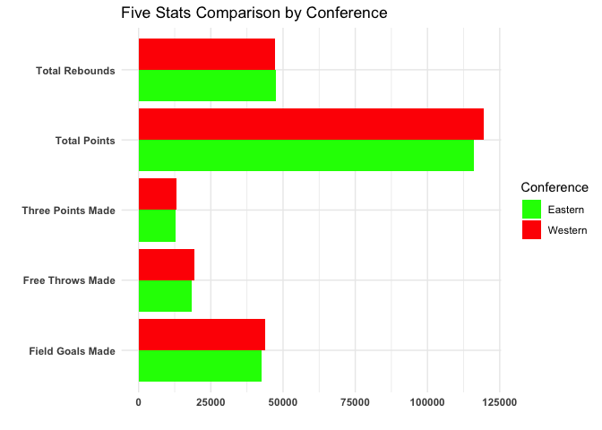

```r
library(ggplot2)
library(tidyr)

EastStat <- subset(player_stat, player_stat$Team == "MIL" | player_stat$Team == "TOR" |
                     player_stat$Team == "BOS" | player_stat$Team == "IND" | player_stat$Team == "MIA" |
                     player_stat$Team == "PHI" | player_stat$Team == "BRO" | player_stat$Team == "ORL" |
                     player_stat$Team == "WAS" | player_stat$Team == "CHA" | player_stat$Team == "CHI" |
                     player_stat$Team == "NYK" | player_stat$Team == "DET" | player_stat$Team == "ATL" |
                     player_stat$Team == "CLE")
WestStat <- subset(player_stat, player_stat$Team == "LAL" | player_stat$Team == "LAC" |
                     player_stat$Team == "DEN" | player_stat$Team == "HOU" | player_stat$Team == "OKL" |
                     player_stat$Team == "UTA" | player_stat$Team == "DAL" | player_stat$Team == "POR" |
                     player_stat$Team == "MEM" | player_stat$Team == "PHO" | player_stat$Team == "SAN" |
                     player_stat$Team == "SAC" | player_stat$Team == "NOR" | player_stat$Team == "MIN" |
                     player_stat$Team == "GSW")

EastStat$Conf <- "Eastern"
WestStat$Conf <- "Western"

AllConf <- rbind(EastStat, WestStat)

FGM_by_Conf <- setNames(aggregate(x = AllConf$FieldGoalsMade, by = list(AllConf$Conf), FUN = sum),
                        c("Conference", "Field Goals Made"))
THR_by_Conf <- setNames(aggregate(x = AllConf$ThreesMade, by = list(AllConf$Conf), FUN = sum),
                        c("Conference", "Three Points Made"))
FTM_by_Conf <- setNames(aggregate(x = AllConf$FreeThrowsMade, by = list(AllConf$Conf), FUN = sum),
                        c("Conference", "Free Throws Made"))
TRB_by_Conf <- setNames(aggregate(x = AllConf$TotalRebounds, by = list(AllConf$Conf), FUN = sum),
                        c("Conference", "Total Rebounds"))
TP_by_Conf <- setNames(aggregate(x = AllConf$TotalPoints, by = list(AllConf$Conf), FUN = sum),
                       c("Conference", "Total Points"))

AllMerged <- merge(merge(merge(merge(FGM_by_Conf, THR_by_Conf), FTM_by_Conf), TRB_by_Conf), TP_by_Conf)

AllMergedGathered <- gather(AllMerged, Stats, Records, -Conference)
ggplot(AllMergedGathered, aes(x = Stats, y = Records, fill = factor(Conference))) +
  geom_bar(stat = 'identity', position = 'dodge') + theme_minimal() +
  scale_fill_discrete(name = "Conference") +
  scale_fill_manual("Conference", values = c("Eastern" = "green", "Western" = "red")) +
  theme(axis.text.x = element_text(face = "bold")) + theme(axis.text.y = element_text(face = "bold")) +
  ggtitle("Five Stats Comparison by Conference") + xlab('') + ylab('') +
  coord_flip()
```

The comparison above reflects every Eastern and Western conference team. As we can see, the Western statistics are slightly higher than the Eastern, but the difference does not seem to be meaningfully significant. Although it shows only the 19-20 season along with just five statistics, which are not enough to make a conclusion, as a general fan of NBA, I believe both conferences are the best basketball leagues in the world.

2. Fouls by position of top 5 Western teams

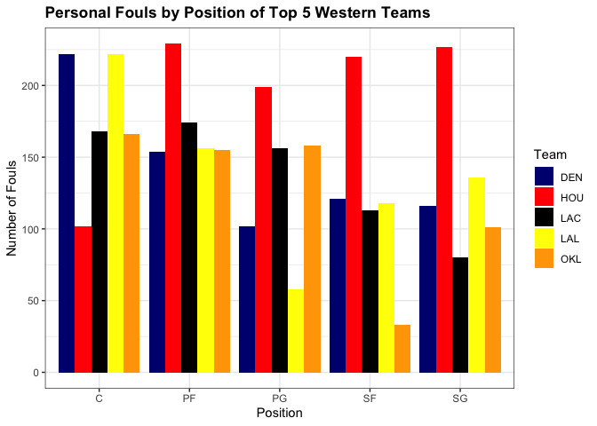

```r
west_top5 <- subset(nba1920, nba1920$Team == "LAL" | nba1920$Team == "LAC" | nba1920$Team == "DEN" |
                      nba1920$Team == "HOU" | nba1920$Team == "OKL")

foul_by_pos <- west_top5[, c("Team", "Position", "PersonalFouls")]
ggplot(foul_by_pos, aes(x = Position, y = PersonalFouls, fill = Team)) +
  geom_bar(stat = 'identity', position = 'dodge') +
  ggtitle("Personal Fouls by Position of Top 5 Western Teams") +
  scale_fill_manual("Team", values = c("DEN" = "navy blue", "HOU" = "red", "LAC" = "black",
                                       "LAL" = "yellow", "OKL" = "orange")) +
  ylab("Number of Fouls") + theme_bw() + theme(plot.title = element_text(face = "bold"))
```

The graph compares top 5 Western Conference teams in the season. Houston Rockets players committed many more fouls than other teams except Centers. By position, Centers and Power Forward similarly committed fouls except Houston Rockets, and LA Lakers Point Guards made the minimum fouls, while OKL City Thunder Small Forwards committed the minimum fouls. Lastly, the shooting guard of LA Clippers made the least fouls.

3. Number of Views on NBA Final

```r
final_views <- read_html("https://en.wikipedia.org/wiki/NBA_Finals_television_ratings")
final_views_data <- final_views %>% html_nodes("table.wikitable")

views_by_year <- (final_views_data[2] %>% html_table(fill = TRUE))[[1]]
views_by_year <- views_by_year[, 1:ncol(views_by_year) - 1]

views_by_year$Year <- gsub('\\[a]', '', views_by_year$Year)

views_by_year$Avg <- gsub("[a-z]", "", views_by_year$Avg)
views_by_year$Avg <- gsub("[A-Z]", "", views_by_year$Avg)
views_by_year$Avg <- gsub(".*\\((.*)\\).*", "\\1", views_by_year$Avg)

views_by_year$Avg <- as.numeric(views_by_year$Avg)
```

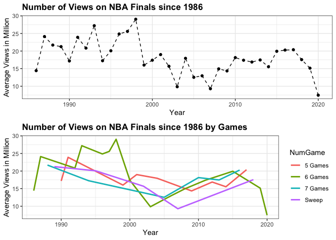

```r
views_by_year$Year <- as.numeric(views_by_year$Year)

views_by_year <- views_by_year[1:35, ] #Before 1986, there's no data of number of views, so truncated
views_by_year$NumGame <- ifelse(views_by_year$`Game 5` == "No Game" & !is.na(views_by_year$`Game 5`),
                                "Sweep", views_by_year$`Game 5`)
views_by_year$NumGame <- ifelse(views_by_year$`Game 5` != "No Game" & views_by_year$`Game 6` == "No Game" &
                                  !is.na(views_by_year$`Game 6`), "5 Games", views_by_year$NumGame)
views_by_year$NumGame <- ifelse(views_by_year$`Game 5` != "No Game" & views_by_year$`Game 6` != "No Game" &
                                  views_by_year$`Game 7` == "No Game" & !is.na(views_by_year$`Game 7`),
                                "6 Games", views_by_year$NumGame)
views_by_year$NumGame <- ifelse(views_by_year$`Game 5` != "No Game" & views_by_year$`Game 6` != "No Game" &
                                  views_by_year$`Game 7` != "No Game" & !is.na(views_by_year$`Game 7`),
                                "7 Games", views_by_year$NumGame)

library(gridExtra)
a <- ggplot(views_by_year, aes(x = Year, y = Avg)) + geom_line(linetype = 'dashed') + geom_point() +
  ggtitle("Number of Views on NBA Finals since 1986") + ylab("Average Views in Million") + theme_bw() +
  theme(plot.title = element_text(face = "bold"))

b <-ggplot(views_by_year, aes(x = Year, y = Avg, group = NumGame, colour = NumGame)) + geom_line(size = 1) +
  ggtitle("Number of Views on NBA Finals since 1986 by Games") + ylab("Average Views in Million") +
  theme_bw() + theme(plot.title = element_text(face = "bold"))

grid.arrange(a, b, nrow = 2)
```

Those graphs show the number of views on NBA Finals since 1986. Unfortunately, 2020 NBA final recorded the lowest views since 1986. NBA had a tough time in this year due to COVID-19, which seems to impact even the number of views on final games. Also, the number of views significantly dropped after 1990s. This seems to be due to the retirement of the greatest basket player, Michael Jordan (mostly retired in 90s as he retired several times).

The second graph shows the number of views by number of final games. The sweep games are slightly less viewed than others, which means that the more final games, the higher likelihood of more views.

4. Five NBA Star Players Stat Comparison

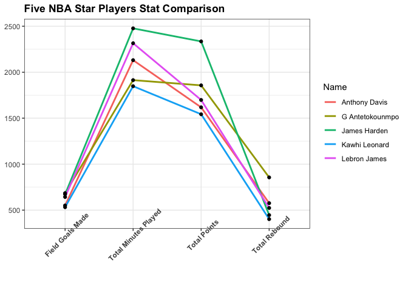

```r
star_players <- subset(nba1920, nba1920$Name == "Lebron James" | nba1920$Name == "G Antetokounmpo" |
                       nba1920$Name == "Anthony Davis" | nba1920$Name == "James Harden" |
                       nba1920$Name == "Kawhi Leonard")

TMP <- setNames(aggregate(x = star_players$TotalMinutesPlayed, by = list(star_players$Name), FUN = sum),
                c("Name", "Total Minutes Played"))
TP <- setNames(aggregate(x = star_players$TotalPoints, by = list(star_players$Name), FUN = sum),
               c("Name", "Total Points"))
TR <- setNames(aggregate(x = star_players$TotalRebounds, by = list(star_players$Name), FUN = sum),
                c("Name", "Total Rebound"))
FGM <- setNames(aggregate(x = star_players$FieldGoalsMade, by = list(star_players$Name), FUN = sum),
                c("Name", "Field Goals Made"))

AllMerged2 <- merge(merge(merge(TMP, TP), TR), FGM)

AllMerged2_gathered <- gather(AllMerged2, Stats, Records, -Name)

ggplot(AllMerged2_gathered, aes(x = Stats, y = Records, group = Name, colour = Name)) +
  geom_line(size = 1) + geom_point(color = 'black') + theme_bw() +
  ggtitle("Five NBA Star Players Stat Comparison") + scale_fill_discrete(name = "Players") +
  theme(axis.text.x = element_text(angle = 45, face = "bold")) + xlab(NULL) + ylab(NULL) +
  theme(plot.title = element_text(face = "bold"))
```

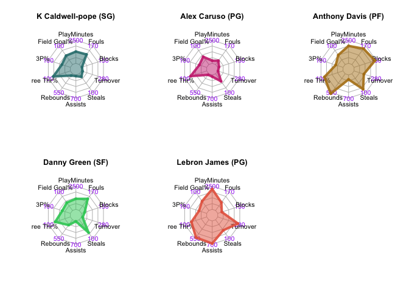

```r
library(fmsb)

LAL_lineups <- nba1920[nba1920$Name == "Alex Caruso" | nba1920$Name == "Anthony Davis" | nba1920$Name == "Danny Green" |
                  nba1920$Name == "K Caldwell-pope" | nba1920$Name == "Lebron James",
                  c("TotalMinutesPlayed", "FieldGoalsMade", "FieldGoalsAttempted", "ThreesMade", "ThreesAttempted", "FreeThrowsMade",
                    "FreeThrowsAttempted", "TotalRebounds", "Assists", "Steals", "Turnovers", "Blocks", "PersonalFouls")]
LAL_lineups$`Field Goal%` <- LAL_lineups$FieldGoalsMade / LAL_lineups$FieldGoalsAttempted * 100
LAL_lineups$`3P%` <- LAL_lineups$ThreesMade / LAL_lineups$ThreesAttempted * 100
LAL_lineups$`Free Thr%` <- LAL_lineups$FreeThrowsMade / LAL_lineups$FreeThrowsAttempted * 100
LAL_lineups <- LAL_lineups[c("TotalMinutesPlayed", "Field Goal%", "3P%", "Free Thr%",
                             "TotalRebounds", "Assists", "Steals", "Turnovers", "Blocks", "PersonalFouls")]
rownames(LAL_lineups) <- c("K Caldwell-pope", "Alex Caruso", "Anthony Davis", "Danny Green", "Lebron James")
colnames(LAL_lineups) <- c("PlayMinutes", "Field Goal%", "3P%", "Free Thr%", "Rebounds", "Assists", "Steals", "Turnovers", "Blocks",
                           "Fouls")
LAL_lineups <- rbind(c(2500, 100, 100, 100, 550, 700, 100, 280, 150, 170), c(1000, 0, 0, 0, 100, 80, 50, 50, 10, 80), LAL_lineups)

par(mfrow = c(2,3))
radarchart(LAL_lineups[1:3, ], title = "K Caldwell-pope (SG)", axistype = 2, pcol=rgb(0.2,0.5,0.5,0.9), pfcol=rgb(0.2,0.5,0.5,0.5),
           plwd=4, cglcol="grey", cglty=1, axislabcol="purple")
radarchart(LAL_lineups[c(1,2,4),], title = "Alex Caruso (PG)", axistype = 2, pcol=rgb(0.8,0.2,0.5,0.9), pfcol=rgb(0.8,0.2,0.5,0.5),
           plwd=4, cglcol="grey", cglty=1, axislabcol="purple")
radarchart(LAL_lineups[c(1,2,5),], title = "Anthony Davis (PF)", axistype = 2, pcol=rgb(0.7,0.5,0.1,0.9), pfcol=rgb(0.7,0.5,0.1,0.5),
           plwd=4, cglcol="grey", cglty=1, axislabcol="purple")
radarchart(LAL_lineups[c(1,2,6),], title = "Danny Green (SF)", axistype = 2, pcol=rgb(0.2,0.8,0.4,0.9), pfcol=rgb(0.2,0.8,0.4,0.5),
           plwd=4, cglcol="grey", cglty=1, axislabcol="purple")
radarchart(LAL_lineups[c(1,2,7),], title = "Lebron James (PG)", axistype = 2, pcol=rgb(0.9,0.4,0.3,0.9), pfcol=rgb(0.9,0.4,0.3,0.5),
           plwd=4, cglcol="grey", cglty=1, axislabcol="purple")
par(mfrow = c(1,1))
```

The radar charts concern 10 statistics in order to assess each position of LA Lakers starting lineup. - Total minutes played - % of field goals success (field goals made / attempts) - % of three points success (3P made / attempts) - % of free throws success (free throws made / attempts) - Total rebounds - Assists - Steals - Turnovers - Blocks - Fouls

6. Offensive Rebounds vs Defensive Rebounds for Turnovers

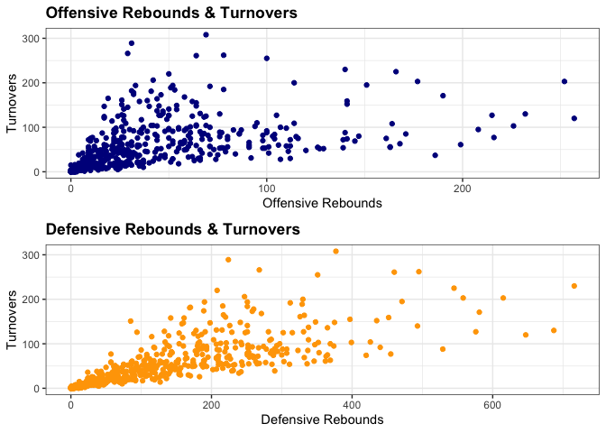

```r
nba1920$DefensiveRebounds <- nba1920$TotalRebounds - nba1920$OffensiveRebounds

x <- ggplot(nba1920, aes(x = OffensiveRebounds, y = Turnovers)) + geom_point(color = "dark blue") +
  theme_bw() + ggtitle("Offensive Rebounds & Turnovers") + xlab("Offensive Rebounds") +
  theme(plot.title = element_text(face = "bold"))

y <- ggplot(nba1920, aes(x = DefensiveRebounds, y = Turnovers)) + geom_point(color = "orange") +
  theme_bw() + ggtitle("Defensive Rebounds & Turnovers") + xlab("Defensive Rebounds") +
  theme(plot.title = element_text(face = "bold"))

grid.arrange(x,y, nrow = 2)
```

There are two kinds of rebounds: offensive and defensive. Offensive rebounds mean that the offensive side recovered the ball so that they keep possessing their turn, while defensive rebounds mean that the defending side gains the possession and the turn changes. Regardless of the types of rebounds, generally the more rebounds the more turnovers. However, if we take a deeper look inside with these two separate rebound types, defensive rebounds have more strong correlation with turnovers than offensive rebounds do. This implies that if the team fails in offensive rebounds, turnovers are more likely to occur than in case the team fails in defensive rebounds.

5. Displaying the home locations of the last 10 champions of the league with GoogleVis

```r
library(googleVis)
library(dplyr)
library(tmap)
library(tmaptools)

NBA_Champs <- read_html("https://en.wikipedia.org/wiki/List_of_NBA_champions")
NBA_Champs_data <- NBA_Champs %>% html_nodes("table.wikitable")

Champs <- (NBA_Champs_data[2] %>% html_table())[[1]]
Champs <- tail(Champs, 10) %>% select(Year,`Western champion`,Result,`Eastern champion`)

Champs$`Eastern champion` <- gsub("\\s.*", "", Champs$`Eastern champion`)
Champs$`Western champion` <- gsub("^(\\S*\\s+\\S+).*", "\\1", Champs$`Western champion`)
Champs$`Western champion` <- gsub("Golden State", "San Francisco", Champs$`Western champion`)
Champs$`Western champion` <- gsub("Mavericks", "", Champs$`Western champion`)

Champs$WestWins <- as.numeric(substr(Champs$Result,1,1))
Champs$EastWins <- as.numeric(substr(Champs$Result,3,3))
Champs$Winner <- ifelse(Champs$WestWins > Champs$EastWins, Champs$`Western champion`, Champs$`Eastern champion`)

latlong <- geocode_OSM(unique(Champs$Winner))
latlong <- as_tibble(latlong) %>% rename(Winner = query)

newChamps <- Champs %>% inner_join(latlong)
```

```r
newChamps$LatLong <- paste(as.character(newChamps$lat), as.character(newChamps$lon), sep = ":")
newChamps$state <- c("Texas", "Florida", "Florida", "Texas", "California", "Ohio", rep("California", 2),
                     "Ontario", "California")

stateChart <- gvisGeoChart(newChamps, "state",
                           options = list(region = "US", resolution = 'provinces'))
cityChart <- gvisGeoChart(newChamps, "LatLong",
                          options = list(region = "US", resolution = 'provinces'))

plot(stateChart)
```

[output not shown]

```
## starting httpd help server ...
```

```
##  done
```

```r
plot(cityChart)
```

[output not shown]

6. Simple Linear Regression for Total Points by Field Goals Attempted (See comments for the equation)

```r
cor(nba1920$FieldGoalsAttempted, nba1920$TotalPoints)  #Field Goals Attempted has a high correlation coefficient with total points
```

```
## [1] 0.9895421
```

```r
m <- lm(TotalPoints~FieldGoalsAttempted, data = nba1920)
summary(m)    #The equation of the model is y = -14.131 + 1.3x, meaning that each field goal attempt increases 1.3 total points
```

```
##
## Call:
## lm(formula = TotalPoints ~ FieldGoalsAttempted, data = nba1920)
##
## Residuals:
##     Min      1Q  Median      3Q     Max
## -190.44  -30.25    3.61   18.11  383.42
##
## Coefficients:
##                       Estimate Std. Error t value Pr(>|t|)
## (Intercept)         -14.130523   3.970253  -3.559 0.000406 ***
## FieldGoalsAttempted   1.298354   0.008244 157.485  < 2e-16 ***
## ---
## Signif. codes:  0 '***' 0.001 '**' 0.01 '*' 0.05 '.' 0.1 ' ' 1
##
## Residual standard error: 61.57 on 527 degrees of freedom
## Multiple R-squared:  0.9792, Adjusted R-squared:  0.9792
## F-statistic: 2.48e+04 on 1 and 527 DF,  p-value: < 2.2e-16
```

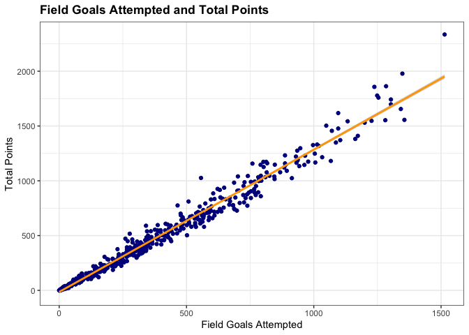

```r
ggplot(nba1920,aes(x = FieldGoalsAttempted, y = TotalPoints)) + geom_point(color = 'dark blue') +
  geom_smooth(method = "lm", color = 'orange') + theme_bw() +
  ggtitle("Field Goals Attempted and Total Points") + xlab("Field Goals Attempted") +
  ylab("Total Points") + theme(plot.title = element_text(face = "bold"))
```

Also, below is the interactive plot with ggPredict() for this simple linear regression. Note that Rmd / md file doesn’t support the interactive plot, so please use R script for this part.

```r
library(ggiraph)
library(ggiraphExtra)
library(plyr)
ggPredict(m, se = TRUE, interactive = TRUE)
```

[interactive chart not shown]